# Estimating and applying detectability offsets

Analysing Ecological Data with Detection Error

Author

Péter Sólymos

Published

April 22, 2026

# Preamble

```r
library(mefa4) # data manipulation
```

```
mefa4 0.3-12     2025-07-12
```

```r
library(mgcv) # GAMs
library(pscl) # zero-inflated models
library(lme4) # GLMMs
library(MASS) # Negative Binomial GLM
library(partykit) # regression trees
library(intrval) # interval magic
library(opticut) # optimal partitioning
```

```
opticut 0.1-4    2025-07-12
```

```r
library(visreg) # regression visualization
library(ResourceSelection) # marginal effects
```

```
ResourceSelection 0.3-6      2023-06-27
```

```r
library(MuMIn) # multi-model inference
library(detect)
```

```
detect 0.5-1     2026-01-04
```

```r
set.seed(1234)

x <- detect::josm$surveys
x$FOR <- x$Decid + x$Conif + x$ConifWet # forest
x$AHF <- x$Agr + x$UrbInd + x$Roads # 'alienating' human footprint
x$WET <- x$OpenWet + x$ConifWet + x$Water # wet + water
cn <- c(
    "Open", "Water", "Agr", "UrbInd", "SoftLin", "Roads", "Decid",
    "OpenWet", "Conif", "ConifWet"
)
x$HAB <- droplevels(find_max(x[, cn])$index) # drop empty levels
levels(x$HAB)[levels(x$HAB) %in%
    c("OpenWet", "Water", "Open", "Agr", "UrbInd", "Roads")] <- "Open"
levels(x$HAB)[levels(x$HAB) %in%
    c("Conif", "ConifWet")] <- "Conif"
x$OBS <- as.factor(x$ObserverID)
```

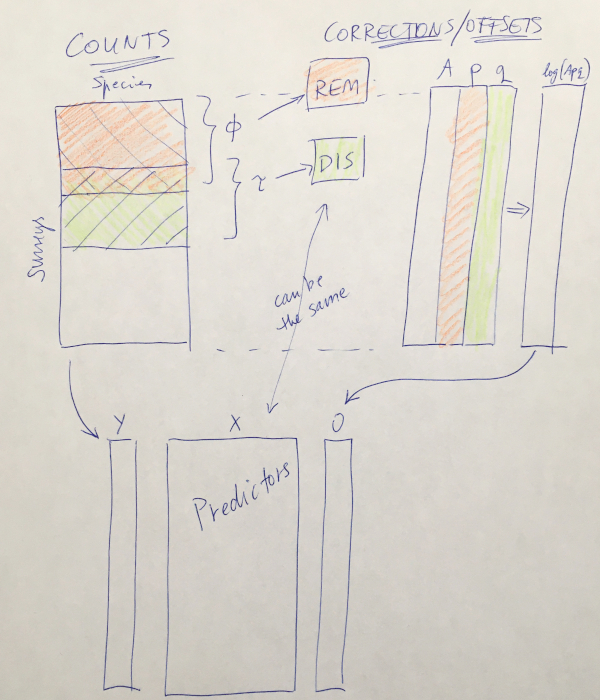

## Duration and distance intervals

```r
cts <- josm$counts[josm$counts$DetectType1 != "V", ]
cts$DurDis <- paste(cts$Dur, cts$Dis)
table(cts$DurDis)
```

```
   0-3min 0-50m    0-3min 100+m  0-3min 50-100m    3-5min 0-50m    3-5min 100+m
          15520            3424           13981            2627            1265
 3-5min 50-100m   5-10min 0-50m   5-10min 100+m 5-10min 50-100m
           3130            4285            1893            4863
```

```r
ydurdis <- Xtab(~ SiteID + DurDis + SpeciesID, cts)
```

Create count for different methodologies

```r
spp <- "OVEN"
y <- as.matrix(ydurdis[[spp]])
yc <- cbind(
    "3min/50m" = y[, "0-3min 0-50m"],
    "5min/50m" = y[, "0-3min 0-50m"] + y[, "3-5min 0-50m"],
    "10min/50m" = rowSums(y[, c("0-3min 0-50m", "3-5min 0-50m", "5-10min 0-50m")]),
    "3min/100m" = rowSums(y[, c("0-3min 0-50m", "0-3min 50-100m")]),
    "5min/100m" = rowSums(y[, c(
        "0-3min 0-50m", "3-5min 0-50m",
        "0-3min 50-100m", "3-5min 50-100m"
    )]),
    "10min/100m" = rowSums(y[, c(
        "0-3min 0-50m", "3-5min 0-50m", "5-10min 0-50m",
        "0-3min 50-100m", "3-5min 50-100m", "5-10min 50-100m"
    )]),
    "3min/Infm" = rowSums(y[, c(
        "0-3min 0-50m",
        "0-3min 50-100m", "0-3min 100+m"
    )]),
    "5min/Infm" = rowSums(y[, c(
        "0-3min 0-50m", "3-5min 0-50m",
        "0-3min 50-100m", "3-5min 50-100m",
        "0-3min 100+m", "3-5min 100+m"
    )]),
    "10min/Infm" = rowSums(y[, c(
        "0-3min 0-50m", "3-5min 0-50m", "5-10min 0-50m",
        "0-3min 50-100m", "3-5min 50-100m", "5-10min 50-100m",
        "0-3min 100+m", "3-5min 100+m", "5-10min 100+m"
    )])
)
```

See how mean counts are different:

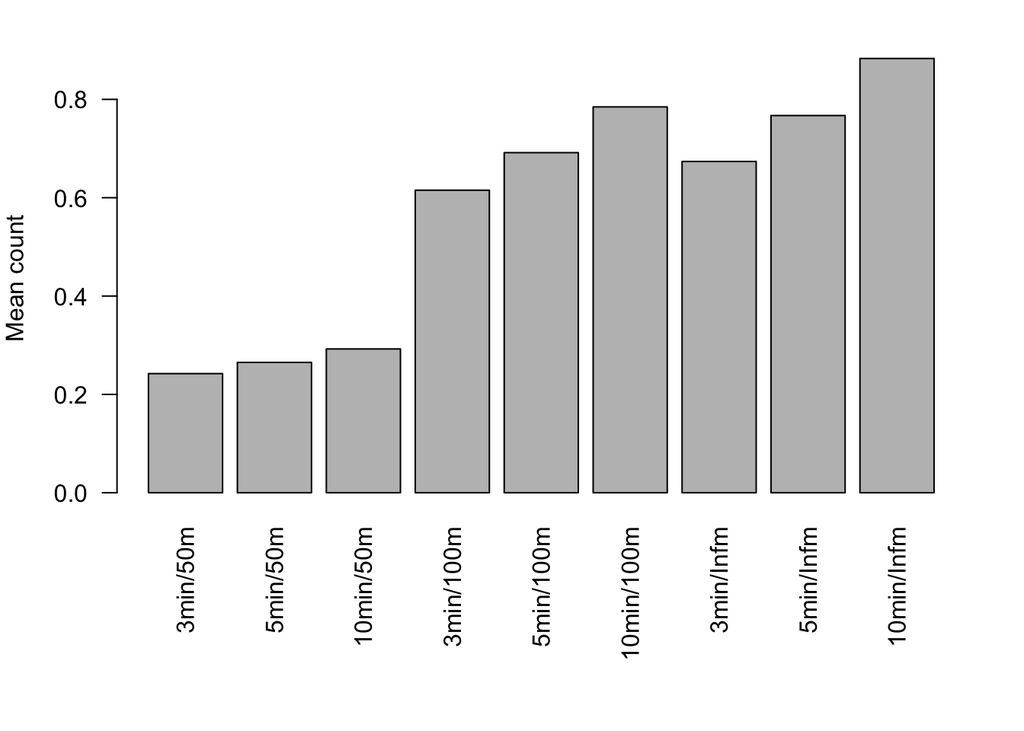

```r
op <- par(mar = c(8, 4, 2, 2), las = 2)
barplot(colMeans(yc), ylab = "Mean count")
```

```r
par(op)
```

Removal model

```r
Ydur <- as.matrix(Xtab(~ SiteID + Dur + SpeciesID, cts)[[spp]])
Ddur <- matrix(c(3, 5, 10), nrow(Ydur), 3, byrow = TRUE)
Mdur <- cmulti(Ydur | Ddur ~ DAY, x[rownames(Ydur), ], type = "rem")

phi <- drop(exp(model.matrix(Mdur) %*% coef(Mdur)))
summary(phi)
```

```
   Min. 1st Qu.  Median    Mean 3rd Qu.    Max.
 0.4086  0.4196  0.4278  0.4290  0.4394  0.4512
```

Distance sampling

```r
Ydis <- as.matrix(Xtab(~ SiteID + Dis + SpeciesID, cts)[[spp]])
Ddis <- matrix(c(0.5, 1, Inf), nrow(Ydis), 3, byrow = TRUE)
Mdis <- cmulti(Ydis | Ddis ~ HAB, x[rownames(Ydur), ], type = "dis")

tau <- drop(exp(model.matrix(Mdis) %*% coef(Mdis)))
summary(tau)
```

```
   Min. 1st Qu.  Median    Mean 3rd Qu.    Max.
 0.6810  0.7000  0.7000  0.7206  0.7429  0.7429
```

Calculating offsets for the different methodologies (max duration and max distance)

```r
p_fun <- function(t, phi) {
    1 - exp(-t * phi)
}
q_fun <- function(r, tau) {
    tau^2 * (1 - exp(-r^2 / tau^2)) / r^2
}

## availability
p3 <- p_fun(3, phi)
p5 <- p_fun(5, phi)
p10 <- p_fun(10, phi)

## average detection
q50 <- q_fun(0.5, tau)
q100 <- q_fun(1, tau)
## area sampled (known)
A50 <- 0.5^2 * pi
A100 <- 1^2 * pi
## effective area sampled
EA <- tau^2 * pi

## correction factors: C=Apq
Corr <- cbind(
    "3min/50m" = A50 * p3 * q50,
    "5min/50m" = A50 * p5 * q50,
    "10min/50m" = A50 * p10 * q50,
    "3min/100m" = A100 * p3 * q100,
    "5min/100m" = A100 * p5 * q100,
    "10min/100m" = A100 * p10 * q100,
    "3min/Infm" = EA * p3 * 1,
    "5min/Infm" = EA * p5 * 1,
    "10min/Infm" = EA * p10 * 1
)
```

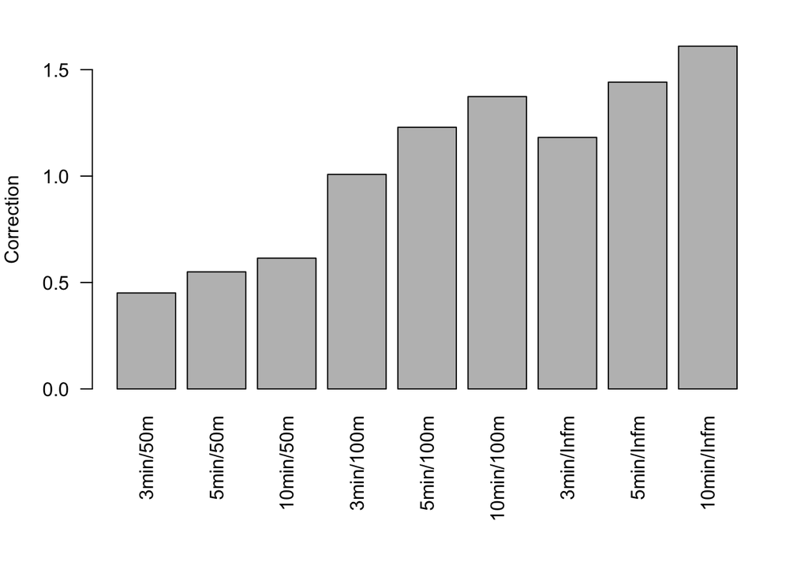

```r
op <- par(mar = c(8, 4, 2, 2), las = 2)
barplot(colMeans(Corr), ylab = "Correction")
```

```r
par(op)
```

See how $E[Y]=DApq$ and thus $\hat{D}=E[Y]/Apq=E[Y]/C$ is going to work. Taking the mean of the $Apq$ term that varies from row to row is not strictly correct (it is correct for constant $\varphi$ and $\tau$)

```r
(D0 <- colMeans(yc) / colMeans(Corr))
```

```
  3min/50m   5min/50m  10min/50m  3min/100m  5min/100m 10min/100m  3min/Infm
 0.5373668  0.4819564  0.4759077  0.6104367  0.5626037  0.5712841  0.5701134
 5min/Infm 10min/Infm
 0.5322467  0.5484187
```

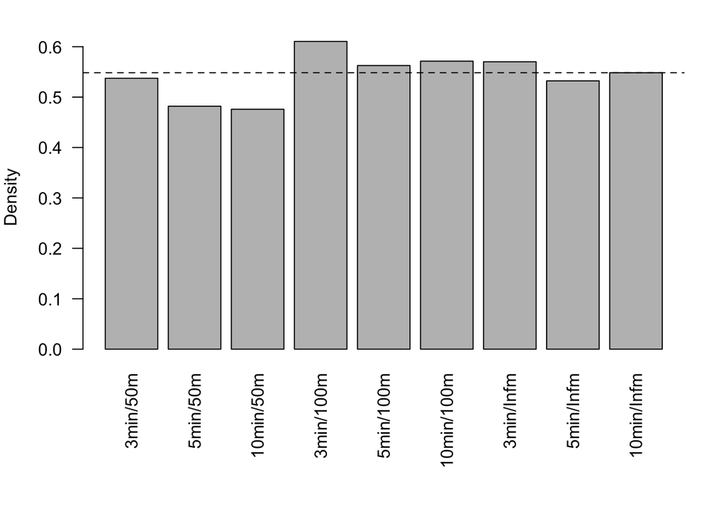

```r
op <- par(mar = c(8, 4, 2, 2), las = 2)
barplot(D0, ylab = "Density")
abline(h = D0["10min/Infm"], lty = 2)
```

```r
par(op)
```

Naive GLM

```r
M1 <- apply(yc, 2, function(z) {
    glm(z ~ Decid, data = x, family = poisson)
})
t(sapply(M1, coef))
```

```
           (Intercept)    Decid
3min/50m     -2.409761 2.051577
5min/50m     -2.338716 2.083917
10min/50m    -2.265081 2.126118
3min/100m    -1.566005 2.202281
5min/100m    -1.459256 2.219651
10min/100m   -1.326642 2.208799
3min/Infm    -1.442896 2.147316
5min/Infm    -1.322982 2.164338
10min/Infm   -1.164268 2.133832
```

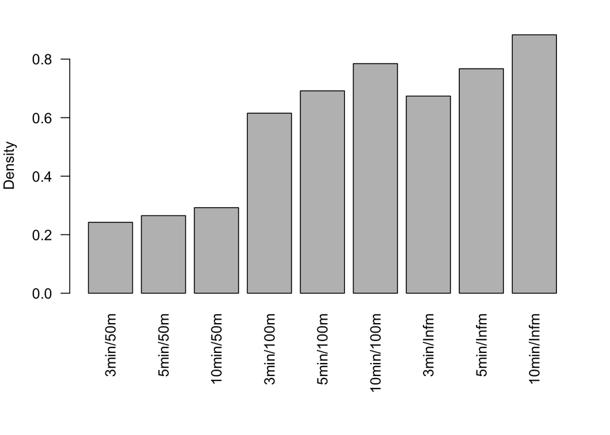

```r
DN <- sapply(M1, function(z) mean(fitted(z)))
op <- par(mar = c(8, 4, 2, 2), las = 2)
barplot(DN, ylab = "Density")
```

```r
par(op)
```

GLM with offsets: offset is the log of the correction factor: $o_i=log(C_i)=log(A_i p_i, q_i)$

```r
Off <- log(Corr)

M2 <- lapply(colnames(yc), function(i) {
    glm(yc[, i] ~ Decid, data = x, family = poisson, offset = Off[, i])
})
names(M2) <- colnames(yc)
t(sapply(M2, coef))
```

```
           (Intercept)    Decid
3min/50m     -1.623378 2.078982
5min/50m     -1.751248 2.112139
10min/50m    -1.788788 2.155212
3min/100m    -1.605653 2.289184
5min/100m    -1.697799 2.307331
10min/100m   -1.676477 2.297545
3min/Infm    -1.657984 2.279331
5min/Infm    -1.736939 2.297082
10min/Infm   -1.689671 2.267898
```

```r
X <- model.matrix(M2[[1]])
DO <- sapply(M2, function(z) mean(exp(X %*% coef(z))))
DO
```

```
  3min/50m   5min/50m  10min/50m  3min/100m  5min/100m 10min/100m  3min/Infm
 0.5404376  0.4848354  0.4788956  0.6226936  0.5740894  0.5830293  0.5874727
 5min/Infm 10min/Infm
 0.5486705  0.5652759
```

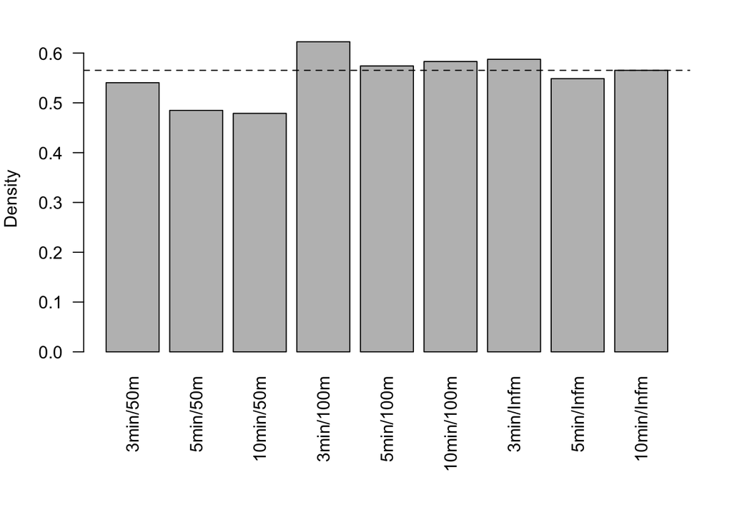

```r
op <- par(mar = c(8, 4, 2, 2), las = 2)
barplot(DO, ylab = "Density")
abline(h = DO["10min/Infm"], lty = 2)
```

```r
par(op)
```

Compare the naive and the offsetted GLM

```r
Dec <- seq(0, 1, 0.05)
Xpred <- cbind(1, Dec)
Fit1 <- sapply(M1, function(z) drop(exp(Xpred %*% coef(z))))
Fit2 <- sapply(M2, function(z) drop(exp(Xpred %*% coef(z))))
```

The 50 m counts under, the 100 and unlimited counts overestimated density compared to the estimate using the offsets

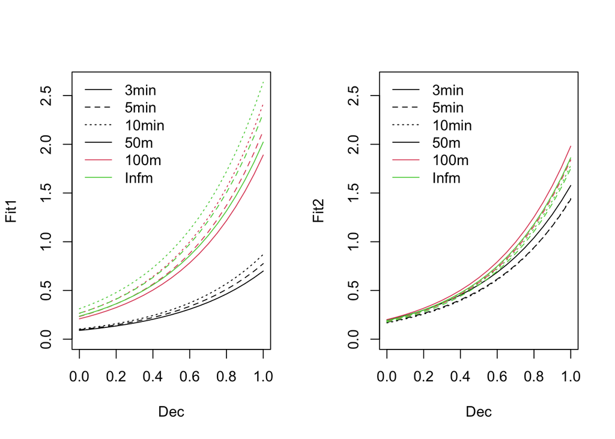

```r
op <- par(mfrow = c(1, 2))
matplot(Dec, Fit1,
    type = "l", ylim = c(0, max(Fit1, Fit2)),
    col = rep(1:3, each = 3), lty = rep(1:3, 3)
)
legend("topleft",
    bty = "n", col = c(1, 1, 1, 1, 2, 3), lty = c(1, 2, 3, 1, 1, 1),
    legend = c("3min", "5min", "10min", "50m", "100m", "Infm")
)
matplot(Dec, Fit2,
    type = "l", ylim = c(0, max(Fit1, Fit2)),
    col = rep(1:3, each = 3), lty = rep(1:3, 3)
)
legend("topleft",
    bty = "n", col = c(1, 1, 1, 1, 2, 3), lty = c(1, 2, 3, 1, 1, 1),
    legend = c("3min", "5min", "10min", "50m", "100m", "Infm")
)
```

```r
par(op)
```

## Different models

Let’s explore models and develop:

- estimation with offset
- prediction without offset

This will be a recipe book that you can use. We just did the Poisson GLM, but repeat it here with the 5 min 100 m counts (you can change this of course). We’ll keep counts, offsets, and the fixed effects the same

```r
x <- x[order(x$Decid), ] # order according to Decid
y <- yc[rownames(x), "5min/100m"]
o <- Off[rownames(x), "5min/100m"]
X <- model.matrix(~Decid, x)
```

### Poisson GLM

```r
## model fit
MP <- glm(y ~ Decid, data = x, family = poisson, offset = o)

## predicting D
DP <- drop(exp(X %*% coef(MP)))
```

### Negative Binomial GLM

```r
MNB <- glm.nb(y ~ Decid + offset(o), data = x)

DNB <- drop(exp(X %*% coef(MNB)))
```

### Zero inflated Poisson

```r
MZIP <- zeroinfl(y ~ Decid | 1, x, dist = "poisson", offset = o)

DZIP <- drop((1 - plogis(coef(MZIP, "zero"))) * exp(X %*% coef(MZIP, "count")))
```

```r
MZINB <- zeroinfl(y ~ Decid | 1, x, dist = "negbin", offset = o)

DZINB <- drop((1 - plogis(coef(MZINB, "zero"))) * exp(X %*% coef(MZINB, "count")))
```

### Occupancy

```r
y01 <- ifelse(y > 0, 1, 0)
MB <- glm(y01 ~ Decid, data = x, family = binomial("cloglog"), offset = o)

## note: we are using exp instead of cloglog inverse link
DB <- drop(exp(X %*% coef(MB)))
```

## Poisson GAM

```r
MPG <- mgcv::gam(y ~ s(Decid), data = x, family = poisson, offset = o)

DPG <- predict(MPG, newdata = x, type = "response")
```

## Poisson-Lognormal GLMM in lme4

```r
MPLN <- glmer(y ~ Decid + (1 | SiteID), data = x, family = poisson, offset = o)

DPLN <- drop(exp(X %*% fixef(MPLN)))
```

### Regression trees

```r
library(gbm)
library(dismo)
library(ggplot2)

xi <- data.frame(
    y = y,
    x[, c(
        "Open", "Water", "Agr", "UrbInd", "SoftLin", "Roads",
        "Decid", "OpenWet", "Conif", "ConifWet", "FOR", "AHF", "WET"
    )]
)
```

```r
# this does k-fold cross validation
brt <- gbm.step(xi,
    gbm.y = 1,
    gbm.x = 2:ncol(xi),
    offset = o,
    family = "poisson",
    tree.complexity = 3,
    learning.rate = 0.01,
    bag.fraction = 0.5
)
DBRT <- predict.gbm(brt, xi, brt$n.trees, type = "response")
```

```r
brt <- gbm(y ~ . + offset(o),
    data = xi,
    n.trees = 1000,
    interaction.depth = 3,
    shrinkage = 0.001,
    bag.fraction = 0.5,
    distribution = "poisson",
    var.monotone = NULL,
    keep.data = FALSE,
    verbose = FALSE,
    n.cores = 1
)
DBRT <- predict.gbm(brt, xi, brt$n.trees, type = "response")
```

Variable importance

```r
rel_inf <- function(res) {
    rel.inf <- relative.influence(res, res$n.trees)
    rel.inf[rel.inf < 0] <- 0
    i <- order(-rel.inf)
    rel.inf <- 100 * rel.inf / sum(rel.inf)
    out <- data.frame(var = res$var.names[i], rel.inf = rel.inf[i])
    attr(out, "n.trees") <- res$n.trees
    out
}
rel_inf(brt)
```

```
              var     rel.inf
Decid       Decid 90.88669848
Conif       Conif  2.72225985
ConifWet ConifWet  1.79845385
AHF           AHF  0.91814063
OpenWet   OpenWet  0.83790217
WET           WET  0.83020905
Roads       Roads  0.76658538
FOR           FOR  0.53838299
Water       Water  0.35996648
SoftLin   SoftLin  0.17702875
Open         Open  0.12083775
UrbInd     UrbInd  0.04353463
Agr           Agr  0.00000000
```

Marginal effects plots

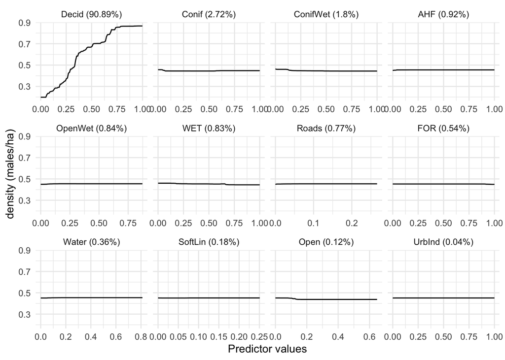

```r
.plot_fun <- function(i, res, u) {
    j <- as.character(u$var[i])
    x <- plot.gbm(res, j,
        n.trees = res$n.trees,
        return.grid = TRUE,
        type = "response",
        ylab = paste(res$rof_settings$spp, "density (males/ha)"),
        xlab = paste0(j, " (", round(u$rel.inf[i], 2), "%)")
    )
    colnames(x) <- c("x", "y")
    x$var <- paste0(j, " (", round(u$rel.inf[i], 2), "%)")
    attr(x, "out.attrs") <- NULL
    x
}
plot_fun <- function(res) {
    u <- rel_inf(res)
    xx <- do.call(rbind, lapply(1:12, .plot_fun, res, u))
    xx$var <- factor(xx$var, unique(xx$var))
    p <- ggplot(xx, aes(x = x, y = y)) +
        geom_line() +
        facet_wrap(vars(var), scales = "free_x") +
        ylab(paste(res$rof_settings$spp, "density (males/ha)")) +
        xlab("Predictor values") +
        theme_minimal()
    p
}
print(plot_fun(brt))
```

### Compare results

```r
AIC(MP, MNB, MZIP, MZINB, MPG, MPLN)
```

```
            df      AIC
MP    2.000000 9568.131
MNB   3.000000 9441.644
MZIP  3.000000 9471.389
MZINB 4.000000 9443.139
MPG   9.718238 9201.855
MPLN  3.000000 9402.942
```

```r
mean(DP)
```

```
[1] 0.5740894
```

```r
mean(DB)
```

```
[1] 0.5003848
```

```r
mean(DNB)
```

```
[1] 0.5829634
```

```r
mean(DZIP)
```

```
[1] 0.5641891
```

```r
mean(DZINB)
```

```
[1] 0.5807734
```

```r
mean(DPG)
```

```
[1] 0.5748426
```

```r
mean(DPLN)
```

```
[1] 0.4722719
```

```r
mean(DBRT)
```

```
[1] 0.5250886
```

## Propagating error

Use the Poisson GLM to show how to propagate uncertainty from the removal and distance model into the GLM

```r
library(MASS)
B <- 100

Xdur <- model.matrix(Mdur)
(cfDur <- coef(Mdur))
```

```
log.phi_(Intercept)         log.phi_DAY
         -0.4496234          -0.8835723
```

```r
(vcvDur <- vcov(Mdur))
```

```
                    log.phi_(Intercept) log.phi_DAY
log.phi_(Intercept)          0.08424602  -0.1879318
log.phi_DAY                 -0.18793177   0.4213039
```

```r
cfBDur <- mvrnorm(B, cfDur, vcvDur)
head(cfBDur)
```

```
     log.phi_(Intercept) log.phi_DAY
[1,]          -0.4970675  -0.8030765
[2,]          -0.4462107  -0.9283042
[3,]          -0.5082371  -0.8205679
[4,]          -0.5643798  -0.5841571
[5,]          -0.7424804  -0.2221936
[6,]          -0.5031387  -0.7470510
```

```r
phiB <- apply(cfBDur, 1, function(z) {
    drop(exp(Xdur %*% z))
})

p5B <- apply(phiB, 2, function(z) p_fun(5, z))
```

```r
Xdis <- model.matrix(Mdis)
(cfDis <- coef(Mdis))
```

```
log.tau_(Intercept)    log.tau_HABDecid    log.tau_HABConif
        -0.38416880          0.02747205          0.08696738
```

```r
(vcvDis <- vcov(Mdis))
```

```
                    log.tau_(Intercept) log.tau_HABDecid log.tau_HABConif
log.tau_(Intercept)         0.004111215     -0.004111215     -0.004111215
log.tau_HABDecid           -0.004111215      0.004216864      0.004111215
log.tau_HABConif           -0.004111215      0.004111215      0.004442186
```

```r
cfBDis <- mvrnorm(B, cfDis, vcvDis)
tauB <- apply(cfBDis, 1, function(z) {
    drop(exp(Xdis %*% z))
})

q100B <- apply(tauB, 2, function(z) q_fun(1, z))

oB <- log(A100 * p5B * q100B)
```

```r
COEF1 <- COEF2 <- matrix(0, B, 2)
for (i in 1:B) {
    ii <- sample.int(nrow(x), nrow(x), replace = TRUE)
    ## no error propagation
    m1 <- glm(y[ii] ~ Decid, data = x[ii, ], family = poisson, offset = o[ii])
    COEF1[i, ] <- coef(m1)
    ## error propagation
    m2 <- glm(y[ii] ~ Decid, data = x[ii, ], family = poisson, offset = oB[ii, i])
    COEF2[i, ] <- coef(m2)
}
apply(COEF1, 2, sd)
```

```
[1] 0.04398377 0.05600997
```

```r
apply(COEF2, 2, sd)
```

```
[1] 0.04463182 0.05752343
```

```r
Xpred2 <- Xpred[c(1, 5, 10, 15, 20), ]
pr1 <- t(apply(
    exp(Xpred2 %*% t(COEF1)), 1,
    quantile, c(0.05, 0.95)
))
pr2 <- t(apply(
    exp(Xpred2 %*% t(COEF2)), 1,
    quantile, c(0.05, 0.95)
))
data.frame(none = pr1, prop = pr2)
```

```
    none.5.  none.95.   prop.5.  prop.95.
1 0.1709263 0.1964008 0.1776560 0.2038206
2 0.2750922 0.3056532 0.2792748 0.3135749
3 0.4982426 0.5374565 0.4894589 0.5369321
4 0.8914404 0.9517870 0.8543183 0.9253648
5 1.5865717 1.7087744 1.4568076 1.6153345
```

## Model validation

Using offsets can have some side effects. Let’s inspect the performance of a null and fixed effect GLM.

When we look at observed vs. predicted based goodness of fit tests or AUC type metrics, we need $\lambda=DApq=D e^{offset}$

```r
M0 <- glm(y ~ 1, data = x, family = poisson, offset = o)
M1 <- glm(y ~ Decid, data = x, family = poisson, offset = o)

lam0 <- drop(exp(X[, 1, drop = FALSE] %*% coef(M0))) * exp(o)
lam1 <- drop(exp(X %*% coef(M1))) * exp(o)
```

Boxplot: when we have different methods mixed together the expected counts can vary greatly (not the case here, because we fixed methodology). Thus offsets can drive the goodness of fit metric.

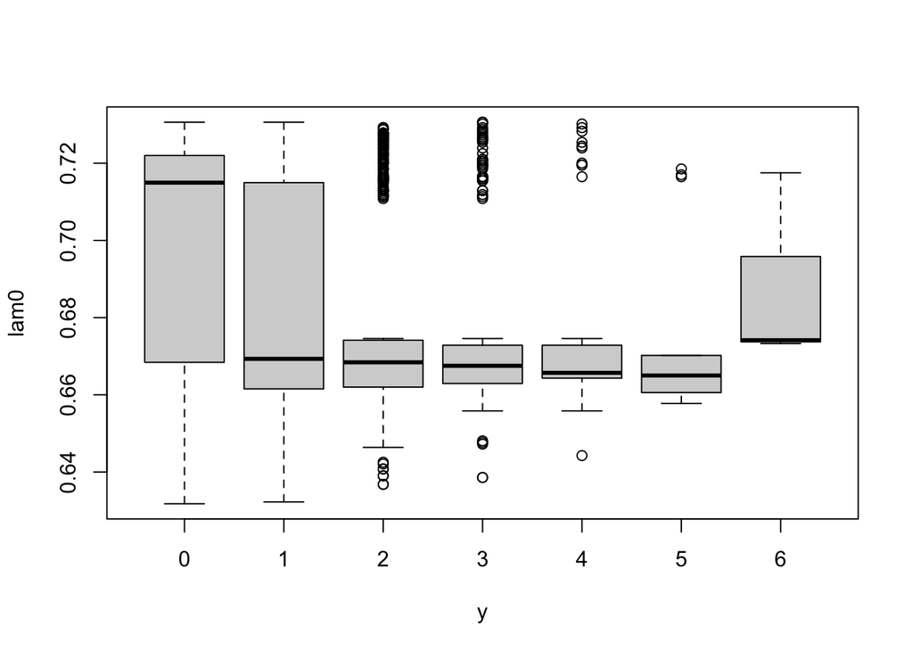

```r
boxplot(lam0 ~ y)
```

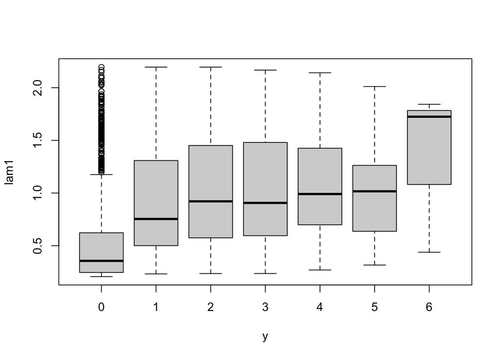

```r
boxplot(lam1 ~ y)
```

```r
simple_roc <- function(labels, scores) {
    Labels <- labels[order(scores, decreasing = TRUE)]
    data.frame(
        TPR = cumsum(Labels) / sum(Labels),
        FPR = cumsum(!Labels) / sum(!Labels),
        Labels = Labels
    )
}
simple_auc <- function(ROC) {
    ROC$inv_spec <- 1 - ROC$FPR
    dx <- diff(ROC$inv_spec)
    sum(dx * ROC$TPR[-1]) / sum(dx)
}
roc0 <- simple_roc(ifelse(y > 0, 1, 0), lam0)
roc1 <- simple_roc(ifelse(y > 0, 1, 0), lam1)
(auc0 <- simple_auc(roc0))
```

```
[1] 0.328372
```

```r
(auc1 <- simple_auc(roc1))
```

```
[1] 0.798886
```

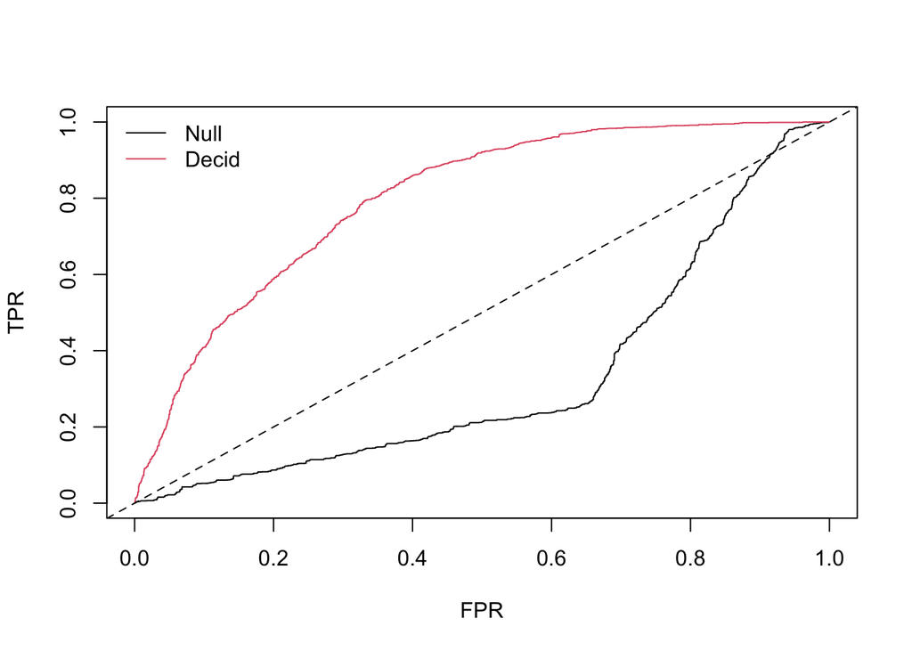

```r
plot(roc0[, 2:1], type = "l")
lines(roc1[, 2:1], col = 2)
abline(0, 1, lty = 2)
legend("topleft", bty = "n", lty = 1, col = c(1, 2), legend = c("Null", "Decid"))
```